# Applied Computational Methods for Social Sciences

## Spatial Join: Share Attribute Table

This is how we can go about it:

```r
#Step1: Reading Spain level-2 borders
esp2 <- st_read(dsn="./data/gadm41_ESP_shp/gadm41_ESP_2.shp", quiet = TRUE)
#Step2: Simplifying polygons
esp2<-st_simplify(esp2, dTolerance=0.01)
#Step3: Selecting only one variable of interest
esp2<-subset(esp2, select=NAME_2)
#Step4: Reading Spain level-4 borders - settlements
esp4 <- st_read(dsn="./data/gadm41_ESP_shp/gadm41_ESP_4.shp", quiet = TRUE)
#Step5: Simplifying polygons
esp4<-st_simplify(esp4, dTolerance=0.01)
#Step6: Selecting only one variable of interest
esp4b<-subset(esp4, select=NAME_4)
#Step7: Creating a unique ID (e.g. some settlements have the same name in multiple counties)
esp4b$unique_id<-as.numeric(rownames(esp4b))
#Step8: Calculating centroid
esp4_pt<-st_centroid(esp4b)
```

## Spatial Join: Share Attribute Table

This is how polygons translate into centroids

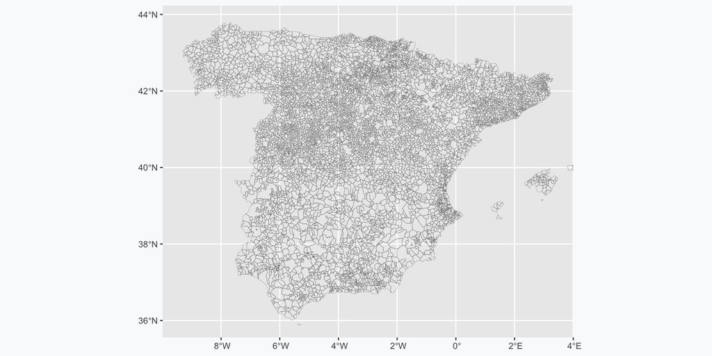

```r
ggplot()+
  geom_sf(data=esp4b, color="black", fill=NA, linewidth=0.05)+
  coord_sf(xlim = c(min_lon_x - error, max_lon_x + error),
           ylim = c(min_lat_y - error, max_lat_y + error))
```

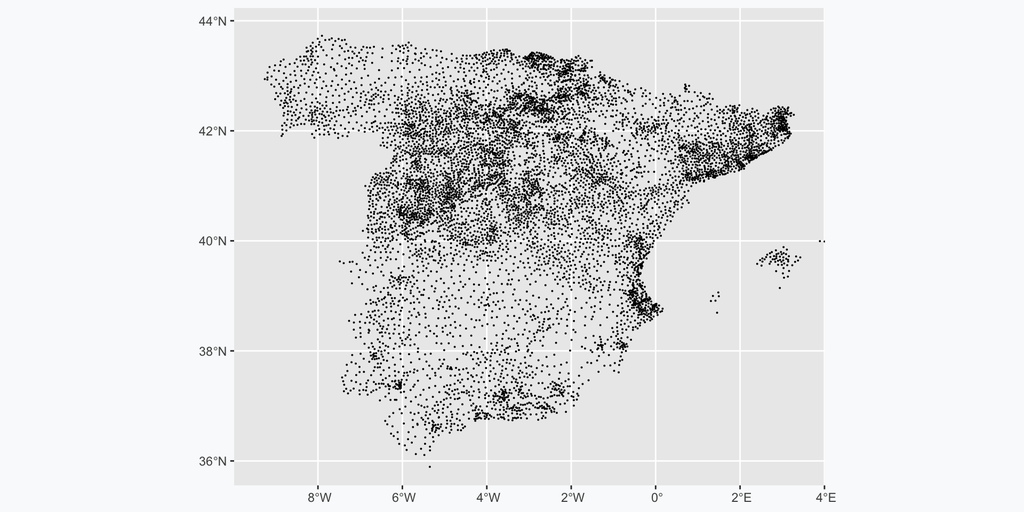

```r
ggplot()+
  geom_sf(data=esp4_pt, color="black", fill=NA, size=0.03)+
  coord_sf(xlim = c(min_lon_x - error, max_lon_x + error),
           ylim = c(min_lat_y - error, max_lat_y + error))
```

## Spatial Join: Share Attribute Table

We then perform the spatial join

We get the points `esp4_pt` (*settlement centroids*) to acquire the attributes of `esp2` (*county polygons*)

```r
#Step9: Perfoming the spatial join
pt_joined<-st_join(esp4_pt, esp2)
#Step10: Dropping the geometry from the object (i.e. turning it into a regular dataframe)
pt_joined_nogeom<-st_drop_geometry(pt_joined)
```

And this is the result:

```r
#Step11: Inspecting the result
head(pt_joined_nogeom, 10)
```

```
                NAME_4 unique_id  NAME_2
1            Albánchez         1 Almería
2                Albox         2 Almería
3             Alcóntar         3 Almería
4             Arboleas         4 Almería
5  Armuña de Almanzora         5 Almería
6              Bacares         6 Almería
7             Bayarque         7 Almería
8             Cantoria         8 Almería
9              Chercos         9 Almería
10               Fines        10 Almería
```

## Spatial Join: Share Attribute Table

This can obviously be mapped

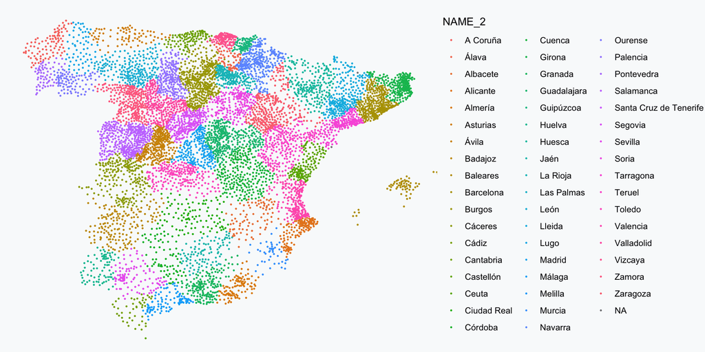

```r
ggplot()+
  geom_sf(data=pt_joined, aes(color=NAME_2),size=0.3)+
  theme_void() +
  coord_sf(xlim = c(min_lon_x - error, max_lon_x + error),
           ylim = c(min_lat_y - error, max_lat_y + error))
```

## Spatial Join: Share Attribute Table

And we can merge the properties of the points to the polygons

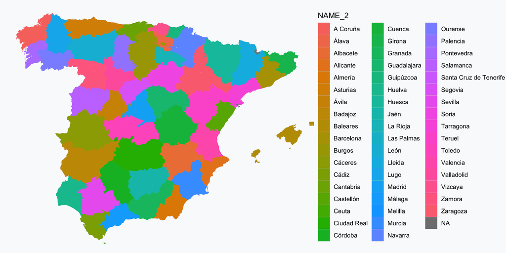

```r
#Step1: Merging point attributes to the polygon attributes
set_poly<-left_join(esp4b, pt_joined_nogeom, by = c("unique_id"="unique_id"))
#Step2: Mapping
ggplot()+
  geom_sf(data=set_poly, aes(color=NAME_2, fill=NAME_2), size=0.2)+
  theme_void() +
  coord_sf(xlim = c(min_lon_x - error, max_lon_x + error),
           ylim = c(min_lat_y - error, max_lat_y + error))
```

## Note

Notice that some settlements have NA values are NA

In this case it it because come centroids can fall outside of the polygon

## Note

Notice that some settlements have NA values are NA

In this case it it because come centroids can fall outside of the polygon

## Note

A potential solution is: `st_point_on_surface`:

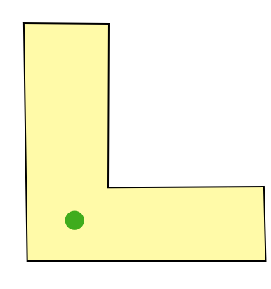

## What Have We Learned?

We practiced more mapping of points and polygons

We covered some important `sf` functions: